# NYPD Shooting Data (Historic)

2023-02-18

## Import libraries that are needed

```r
library(tidyverse)
library(lubridate)
```

```r
library(dplyr)
library(ggplot2)
```

## Problem Statement

I am analyzing data provided by NYPD regarding shooting incidents in New York city. I would try to find where shootings happen most in New York, what time of the day they happen most and what has been trend of shootings over the years.

## Data Description

Data provided by NYPD contains various attributes regarding shooting incidents in New York like which borough, date and time of shooting, information regarding victim and shooter, precinct, whether shooting resulted in murder. Information regarding victim and shooter contains age,race,gender. We also have exact location data but I am not going to use that.

## Load the data, check for missing values, head and summary the data

```r
 nypd_shooting_data <- read_csv("https://data.cityofnewyork.us/api/views/833y-fsy8/rows.csv?accessType=DOWNLOAD")
```

```r
# nypd_shooting_data <- read.csv("NYPD_Shooting_Incident_Data__Historic_.csv")
nrow(nypd_shooting_data)
```

```
## [1] 25596
```

```r
# Let us check rows that miss value for one or more columns
nrow(nypd_shooting_data[complete.cases(na_if(nypd_shooting_data, '')), ])
```

```
## [1] 7243
```

```r
# majority of rows have one or more columns missing values, so we cannot just drop or impute them
# but columns like boro, date, time etc that we want to analyze have no missing values,
# so we are going to leave it as it is
nypd_shooting_data <- nypd_shooting_data %>% drop_na(BORO) %>% drop_na(OCCUR_DATE)

glimpse(nypd_shooting_data)
```

```
## Rows: 25,596
## Columns: 19
## $ INCIDENT_KEY            <dbl> 236168668, 231008085, 230717903, 237712309, 22…
## $ OCCUR_DATE              <chr> "11/11/2021", "07/16/2021", "07/11/2021", "12/…
## $ OCCUR_TIME              <time> 15:04:00, 22:05:00, 01:09:00, 13:42:00, 20:00…
## $ BORO                    <chr> "BROOKLYN", "BROOKLYN", "BROOKLYN", "BROOKLYN"…
## $ PRECINCT                <dbl> 79, 72, 79, 81, 113, 113, 42, 52, 34, 75, 32, …
## $ JURISDICTION_CODE       <dbl> 0, 0, 0, 0, 0, 0, 0, 0, 0, 0, 0, 2, 2, 0, 0, 0…
## $ LOCATION_DESC           <chr> NA, NA, NA, NA, NA, NA, "COMMERCIAL BLDG", NA,…
## $ STATISTICAL_MURDER_FLAG <lgl> FALSE, FALSE, FALSE, FALSE, FALSE, TRUE, TRUE,…
## $ PERP_AGE_GROUP          <chr> NA, "45-64", "<18", NA, NA, NA, NA, NA, NA, "2…
## $ PERP_SEX                <chr> NA, "M", "M", NA, NA, NA, NA, NA, NA, "M", "M"…
## $ PERP_RACE               <chr> NA, "ASIAN / PACIFIC ISLANDER", "BLACK", NA, N…
## $ VIC_AGE_GROUP           <chr> "18-24", "25-44", "25-44", "25-44", "25-44", "…
## $ VIC_SEX                 <chr> "M", "M", "M", "M", "M", "M", "M", "M", "M", "…
## $ VIC_RACE                <chr> "BLACK", "ASIAN / PACIFIC ISLANDER", "BLACK", …
## $ X_COORD_CD              <dbl> 996313, 981845, 996546, 1001139, 1050710, 1051…
## $ Y_COORD_CD              <dbl> 187499, 171118, 187436, 192775, 184826, 196646…
## $ Latitude                <dbl> 40.68132, 40.63636, 40.68114, 40.69579, 40.673…
## $ Longitude               <dbl> -73.95651, -74.00867, -73.95567, -73.93910, -7…
## $ Lon_Lat                 <chr> "POINT (-73.95650899099996 40.68131820000008)"…
```

```r
nrow(nypd_shooting_data)
```

```
## [1] 25596
```

```r
head(nypd_shooting_data)
```

```
## # A tibble: 6 × 19
##   INCIDENT_KEY OCCUR_DATE OCCUR_TIME BORO     PRECINCT JURISDICTION_CODE
##          <dbl> <chr>      <time>     <chr>       <dbl>             <dbl>
## 1    236168668 11/11/2021 15:04      BROOKLYN       79                 0
## 2    231008085 07/16/2021 22:05      BROOKLYN       72                 0
## 3    230717903 07/11/2021 01:09      BROOKLYN       79                 0
## 4    237712309 12/11/2021 13:42      BROOKLYN       81                 0
## 5    224465521 02/16/2021 20:00      QUEENS        113                 0
## 6    228252164 05/15/2021 04:13      QUEENS        113                 0
## # … with 13 more variables: LOCATION_DESC <chr>, STATISTICAL_MURDER_FLAG <lgl>,
## #   PERP_AGE_GROUP <chr>, PERP_SEX <chr>, PERP_RACE <chr>, VIC_AGE_GROUP <chr>,
## #   VIC_SEX <chr>, VIC_RACE <chr>, X_COORD_CD <dbl>, Y_COORD_CD <dbl>,
## #   Latitude <dbl>, Longitude <dbl>, Lon_Lat <chr>
```

```r
summary(nypd_shooting_data)
```

```
##   INCIDENT_KEY        OCCUR_DATE         OCCUR_TIME           BORO
##  Min.   :  9953245   Length:25596       Length:25596      Length:25596
##  1st Qu.: 61593633   Class :character   Class1:hms        Class :character
##  Median : 86437258   Mode  :character   Class2:difftime   Mode  :character
##  Mean   :112382648                      Mode  :numeric
##  3rd Qu.:166660833
##  Max.   :238490103
##
##     PRECINCT      JURISDICTION_CODE LOCATION_DESC      STATISTICAL_MURDER_FLAG
##  Min.   :  1.00   Min.   :0.0000    Length:25596       Mode :logical
##  1st Qu.: 44.00   1st Qu.:0.0000    Class :character   FALSE:20668
##  Median : 69.00   Median :0.0000    Mode  :character   TRUE :4928
##  Mean   : 65.87   Mean   :0.3316
##  3rd Qu.: 81.00   3rd Qu.:0.0000
##  Max.   :123.00   Max.   :2.0000
##                   NA's   :2
##  PERP_AGE_GROUP       PERP_SEX          PERP_RACE         VIC_AGE_GROUP
##  Length:25596       Length:25596       Length:25596       Length:25596
##  Class :character   Class :character   Class :character   Class :character
##  Mode  :character   Mode  :character   Mode  :character   Mode  :character
##
##
##
##
##    VIC_SEX            VIC_RACE           X_COORD_CD        Y_COORD_CD
##  Length:25596       Length:25596       Min.   : 914928   Min.   :125757
##  Class :character   Class :character   1st Qu.:1000011   1st Qu.:182782
##  Mode  :character   Mode  :character   Median :1007715   Median :194038
##                                        Mean   :1009455   Mean   :207894
##                                        3rd Qu.:1016838   3rd Qu.:239429
##                                        Max.   :1066815   Max.   :271128
##
##     Latitude       Longitude        Lon_Lat
##  Min.   :40.51   Min.   :-74.25   Length:25596
##  1st Qu.:40.67   1st Qu.:-73.94   Class :character
##  Median :40.70   Median :-73.92   Mode  :character
##  Mean   :40.74   Mean   :-73.91
##  3rd Qu.:40.82   3rd Qu.:-73.88
##  Max.   :40.91   Max.   :-73.70
##
```

## Clean up the data

```r
shooting_data_clean <- nypd_shooting_data %>%
    mutate(BORO = as_factor(BORO),
         JURISDICTION_CODE = as_factor(JURISDICTION_CODE),
         STATISTICAL_MURDER_FLAG = as_factor(STATISTICAL_MURDER_FLAG),
         MURDER_NUMERIC = as.numeric(STATISTICAL_MURDER_FLAG) - 1,
         LOCATION_DESC = as_factor(LOCATION_DESC),
         VIC_AGE_GROUP = as_factor(VIC_AGE_GROUP),
         VIC_SEX = as_factor(VIC_SEX),
         VIC_RACE = as_factor(VIC_RACE),
         PERP_AGE_GROUP = as_factor(PERP_AGE_GROUP),
         PERP_SEX = as_factor(PERP_SEX),
         PERP_RACE = as_factor(PERP_RACE),
         OCCUR_DATE = as.Date(OCCUR_DATE, format = "%m/%d/%Y"),
         ) %>%
  # Select only the columns we need
  select(OCCUR_DATE, OCCUR_TIME, BORO, PRECINCT,
         STATISTICAL_MURDER_FLAG,  VIC_SEX, VIC_RACE,
         PERP_SEX, PERP_RACE,MURDER_NUMERIC)

# Convert OCCUR_TIME to numeric format to get time in 1600 format
shooting_data_clean$OCCUR_TIME_NUMERIC <- (as.numeric(gsub(":", "", shooting_data_clean$OCCUR_TIME))) / 100

# Print the first 10 rows of the new variable
head(shooting_data_clean$OCCUR_TIME_NUMERIC, 10)
```

```
##  [1] 1504 2205  109 1342 2000  413 2108 1930   18  615
```

```r
# Display the first few rows of the cleaned dataset
head(shooting_data_clean)
```

```
## # A tibble: 6 × 11
##   OCCUR_DATE OCCUR_TIME BORO     PRECINCT STATISTICAL_MURDER_F… VIC_SEX VIC_RACE
##   <date>     <time>     <fct>       <dbl> <fct>                 <fct>   <fct>
## 1 2021-11-11 15:04      BROOKLYN       79 FALSE                 M       BLACK
## 2 2021-07-16 22:05      BROOKLYN       72 FALSE                 M       ASIAN /…
## 3 2021-07-11 01:09      BROOKLYN       79 FALSE                 M       BLACK
## 4 2021-12-11 13:42      BROOKLYN       81 FALSE                 M       BLACK
## 5 2021-02-16 20:00      QUEENS        113 FALSE                 M       BLACK
## 6 2021-05-15 04:13      QUEENS        113 TRUE                  M       BLACK
## # … with 4 more variables: PERP_SEX <fct>, PERP_RACE <fct>,
## #   MURDER_NUMERIC <dbl>, OCCUR_TIME_NUMERIC <dbl>
```

```r
head(shooting_data_clean$MURDER_NUMERIC)
```

```
## [1] 0 0 0 0 0 1
```

```r
# Display a summary of the cleaned dataset
summary(shooting_data_clean)
```

```
##    OCCUR_DATE          OCCUR_TIME                  BORO          PRECINCT
##  Min.   :2006-01-01   Length:25596      BROOKLYN     :10365   Min.   :  1.00
##  1st Qu.:2009-05-10   Class1:hms        QUEENS       : 3828   1st Qu.: 44.00
##  Median :2012-08-26   Class2:difftime   BRONX        : 7402   Median : 69.00
##  Mean   :2013-06-13   Mode  :numeric    MANHATTAN    : 3265   Mean   : 65.87
##  3rd Qu.:2017-07-01                     STATEN ISLAND:  736   3rd Qu.: 81.00
##  Max.   :2021-12-31                                           Max.   :123.00
##
##  STATISTICAL_MURDER_FLAG VIC_SEX                             VIC_RACE
##  FALSE:20668             M:23182   BLACK                         :18281
##  TRUE : 4928             F: 2403   ASIAN / PACIFIC ISLANDER      :  354
##                          U:   11   BLACK HISPANIC                : 2485
##                                    WHITE HISPANIC                : 3742
##                                    WHITE                         :  660
##                                    AMERICAN INDIAN/ALASKAN NATIVE:    9
##                                    UNKNOWN                       :   65
##  PERP_SEX              PERP_RACE     MURDER_NUMERIC   OCCUR_TIME_NUMERIC
##  M   :14416   BLACK         :10668   Min.   :0.0000   Min.   :   0
##  F   :  371   WHITE HISPANIC: 2164   1st Qu.:0.0000   1st Qu.: 323
##  U   : 1499   UNKNOWN       : 1836   Median :0.0000   Median :1510
##  NA's: 9310   BLACK HISPANIC: 1203   Mean   :0.1925   Mean   :1247
##               WHITE         :  272   3rd Qu.:0.0000   3rd Qu.:2045
##               (Other)       :  143   Max.   :1.0000   Max.   :2359
##               NA's          : 9310
```

## Add some new columns

```r
# Create new columns for year, month, and day
shooting_data_clean <- shooting_data_clean %>%
  mutate(YEAR = as.numeric(format(OCCUR_DATE,'%Y')),
         MONTH = month(OCCUR_DATE, label = TRUE),
         DAY = day(OCCUR_DATE))



# Create a new column with time buckets
shooting_data_clean <- shooting_data_clean %>%
  mutate(time_bucket = cut(OCCUR_TIME_NUMERIC, breaks = c(0, 400, 800, 1200, 1600, 2000, 2400), labels = c("1", "2", "3", "4", "5", "6"), include.lowest = TRUE))

# Display the first few rows of the cleaned dataset
head(shooting_data_clean)
```

```
## # A tibble: 6 × 15
##   OCCUR_DATE OCCUR_TIME BORO     PRECINCT STATISTICAL_MURDER_F… VIC_SEX VIC_RACE
##   <date>     <time>     <fct>       <dbl> <fct>                 <fct>   <fct>
## 1 2021-11-11 15:04      BROOKLYN       79 FALSE                 M       BLACK
## 2 2021-07-16 22:05      BROOKLYN       72 FALSE                 M       ASIAN /…
## 3 2021-07-11 01:09      BROOKLYN       79 FALSE                 M       BLACK
## 4 2021-12-11 13:42      BROOKLYN       81 FALSE                 M       BLACK
## 5 2021-02-16 20:00      QUEENS        113 FALSE                 M       BLACK
## 6 2021-05-15 04:13      QUEENS        113 TRUE                  M       BLACK
## # … with 8 more variables: PERP_SEX <fct>, PERP_RACE <fct>,
## #   MURDER_NUMERIC <dbl>, OCCUR_TIME_NUMERIC <dbl>, YEAR <dbl>, MONTH <ord>,
## #   DAY <int>, time_bucket <fct>
```

## Model

```r
shooting_data_yearly <- shooting_data_clean %>%
                        group_by(YEAR) %>%
                        summarize(total_shootings = n(),
                                  total_murders = sum(MURDER_NUMERIC))
shooting_data_yearly <- shooting_data_yearly %>% arrange(YEAR)

train_size <- floor(0.8 * nrow(shooting_data_yearly))
train_data <- shooting_data_yearly %>%
  slice(1:train_size)
test_data <- shooting_data_yearly %>%
  slice((train_size+1):nrow(shooting_data_yearly))

# Fit a logistic regression model to predict STATISTICAL_MURDER_FLAG
#model <- glm(STATISTICAL_MURDER_FLAG ~ BORO + VIC_SEX + YEAR + OCCUR_TIME_NUMERIC, data = train_data, family = binomial())
model_murders <- lm(total_murders ~ YEAR, data = train_data)
summary(model_murders)
```

```
##
## Call:
## lm(formula = total_murders ~ YEAR, data = train_data)
##
## Residuals:
##    Min     1Q Median     3Q    Max
## -57.65 -22.87 -12.15  24.04  61.31
##
## Coefficients:
##              Estimate Std. Error t value Pr(>|t|)
## (Intercept) 42581.800   6449.421   6.602 6.06e-05 ***
## YEAR          -21.014      3.206  -6.554 6.44e-05 ***
## ---
## Signif. codes:  0 '***' 0.001 '**' 0.01 '*' 0.05 '.' 0.1 ' ' 1
##
## Residual standard error: 38.34 on 10 degrees of freedom
## Multiple R-squared:  0.8112, Adjusted R-squared:  0.7923
## F-statistic: 42.96 on 1 and 10 DF,  p-value: 6.44e-05
```

```r
predictions_murders <- predict(model_murders, newdata = test_data, type = "response")


model_shootings <- lm(total_shootings ~ YEAR, data = train_data)
summary(model_shootings)
```

```
##
## Call:
## lm(formula = total_shootings ~ YEAR, data = train_data)
##
## Residuals:
##     Min      1Q  Median      3Q     Max
## -182.63  -97.43  -14.62  107.10  251.78
##
## Coefficients:
##              Estimate Std. Error t value Pr(>|t|)
## (Intercept) 180863.10   24019.84   7.530 1.99e-05 ***
## YEAR           -89.10      11.94  -7.461 2.16e-05 ***
## ---
## Signif. codes:  0 '***' 0.001 '**' 0.01 '*' 0.05 '.' 0.1 ' ' 1
##
## Residual standard error: 142.8 on 10 degrees of freedom
## Multiple R-squared:  0.8477, Adjusted R-squared:  0.8325
## F-statistic: 55.67 on 1 and 10 DF,  p-value: 2.157e-05
```

```r
predictions_shootings <- predict(model_shootings, newdata = test_data, type = "response")

predicted_data <- test_data %>% mutate(pred_murders = floor(predictions_murders),
                                       pred_shootings = floor(predictions_shootings))

predicted_data
```

```
## # A tibble: 4 × 5
##    YEAR total_shootings total_murders pred_murders pred_shootings
##   <dbl>           <int>         <dbl>        <dbl>          <dbl>
## 1  2018             958           204          175           1063
## 2  2019             967           184          154            974
## 3  2020            1948           366          133            885
## 4  2021            2011           428          112            796
```

## Visualization 1 - Bar chart showing number of shootings by boro

### (This plot would be better if we knew population of all boros and could do shootings per thousand or million)

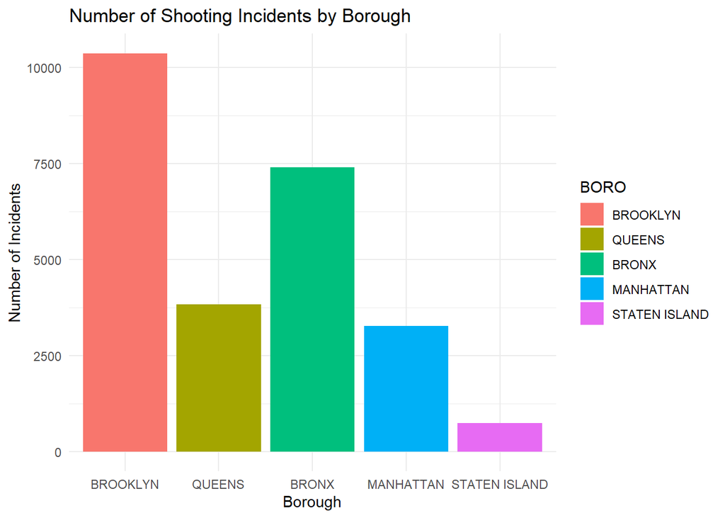

```r
shooting_data_clean %>%
  count(BORO) %>%
  ggplot(aes(x = BORO, y = n, fill = BORO)) +
  geom_col() +
  labs(title = "Number of Shooting Incidents by Borough",
       x = "Borough",
       y = "Number of Incidents") +
  theme_minimal()
```

## Visualization 2 - Plot showing shooting incidents by time of day

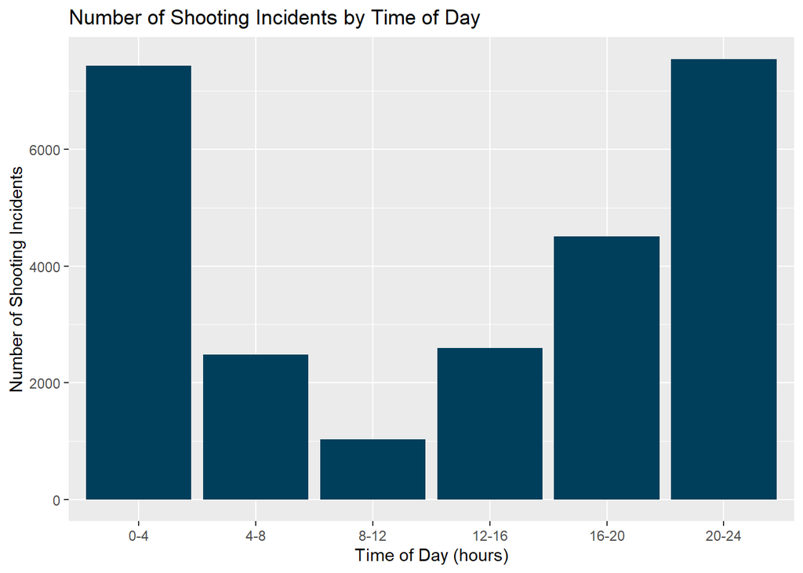

```r
# Count the number of shootings by time bucket
shooting_counts_by_time <- shooting_data_clean %>%
  group_by(time_bucket) %>%
  summarize(count = n())

# Plot the number of shootings by time bucket
ggplot(shooting_counts_by_time, aes(x = time_bucket, y = count)) +
  geom_bar(stat = "identity", fill = "#003f5c") +
  scale_x_discrete(labels = c("0-4", "4-8", "8-12", "12-16", "16-20", "20-24")) +
  labs(title = "Number of Shooting Incidents by Time of Day", x = "Time of Day (hours)", y = "Number of Shooting Incidents")
```

## Visualization 3 - Stack Bar plot showing shooting incidents and murders by year

```r
# Calculate the number of shootings and murders per year
shootings_and_murders_by_year <- shooting_data_clean %>%
  group_by(YEAR, STATISTICAL_MURDER_FLAG) %>%
  summarise(total_incidents = n()) %>%
  ungroup() %>%
  mutate(STATISTICAL_MURDER_FLAG = factor(STATISTICAL_MURDER_FLAG))
```

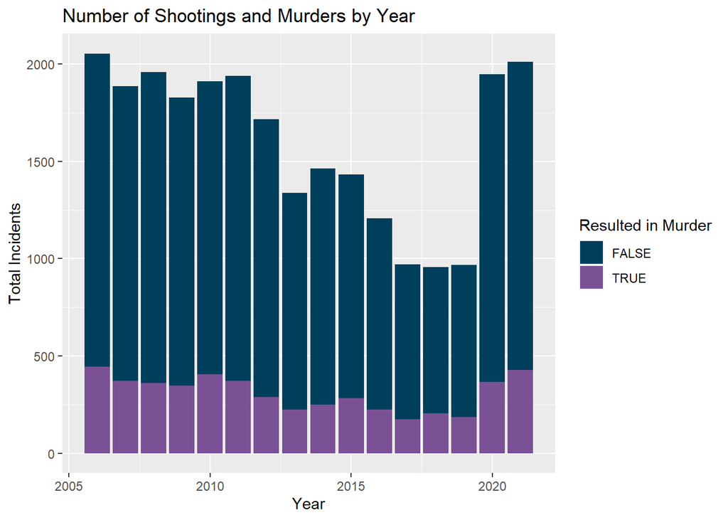

```r
# Plot the number of shootings and murders per year
ggplot(shootings_and_murders_by_year, aes(x = YEAR, y = total_incidents, fill = STATISTICAL_MURDER_FLAG)) +
  geom_col() +
  labs(title = "Number of Shootings and Murders by Year", x = "Year", y = "Total Incidents", fill = "Resulted in Murder") +
  scale_fill_manual(values = c("#003f5c","#7a5195"))
```

## Visualization 4 - Shooting incidents by Year and Boro

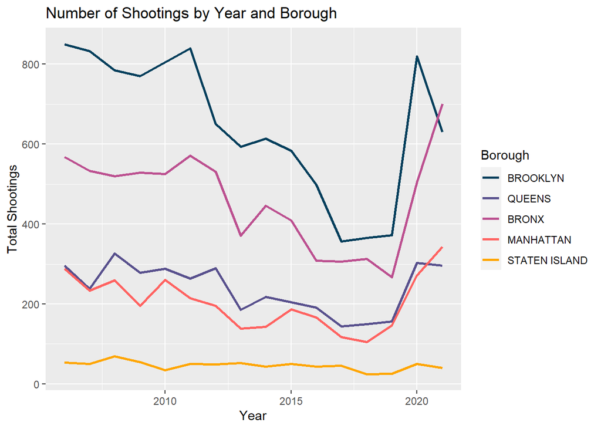

```r
library(ggplot2)

# Calculate the number of shootings per year by borough
shootings_by_borough_and_year <- shooting_data_clean %>%
  group_by(YEAR, BORO) %>%
  summarise(total_shootings = n()) %>%
  ungroup()
# Plot the number of shootings per year by borough
ggplot(shootings_by_borough_and_year, aes(x = YEAR, y = total_shootings, color = BORO)) +
  geom_line(size = 1) +
  labs(title = "Number of Shootings by Year and Borough", x = "Year", y = "Total Shootings", color = "Borough") +
  scale_color_manual(values = c("#003f5c", "#58508d", "#bc5090", "#ff6361", "#ffa600"))
```

## Conclusion

We analyzed the NYPD shooting incident data set, provided by NYC Open Data portal. This data set contained information about shooting incidents like where they occurred, when they occurred and some details about victims and perpetrators.

We started by importing required libraries, importing the data, cleaning it up for type conversions etc. and dropping columns that we did not need. We also added some new columns to help us better analyze. Looked at rows with missing data for various columns and had no missing data for columns that we analyzed.

We found that shooting incident in New York city were going down over period of time but they have gone up again starting 2020. Also, most shooting incidents were reported between 8 pm and 4 am.

This data set may be subject to source of bias such as under reporting of shooting incidents. Data may not fully represent diversity of New York city. Our analysis was limited by available number of variables. Personal bias can also come through our own experience and assumptions like if we know demography of the city and start to analyze based on data. We tried to mitigate that by not making any assumptions.